# Assignment 1

Damilare Olaleye

01/28/2020

```r
library(tidyverse)
```

#### Chapter 1: Review and Introduction to Functions

A basic part of R programming is the function. Here is a simple example of a function that will count the number of odd numbers in a vector of integers.

Note some basic things about a function:

- use keyword `function` and `x` is the input
- surround commands with curly brackets
- output of function is in the `return` statement
- illustrating a `for` loop
- illustrating the modulo operator `%%`

```r
oddcount <- function(x)  {
   k <- 0  # assign 0 to k
   for (n in x)  {
      if (n %% 2 == 1) k <- k + 1  # %% is the modulo operator
   }
   return(k)
}
```

Let’s try it out:

```r
oddcount(4)
```

```
## [1] 0
```

```r
oddcount(c(1, 2, 5, 7, 8))
```

```
## [1] 3
```

#### Question 1

The book says that one could also write the loop using indices:

```
for (i in 1:length(x)){
  if (x[i] %% 2 == 1) k <- k + 1
}
```

Write a new function using this alternative loop and try the function out on a vector of integers.

```r
evenCount <- c(2,4,6,8,10,12,14,16,18,20)

newFunc <- function(x) {
    t <- 0
    for (i in x){
        t <- t + i
    }
    return(t)
}

newFunc(evenCount)
```

```
## [1] 110
```

#### Eliminating Loops

By the way, I think it is more efficient (and quicker) to avoid looping by using vector arithmetic.

I replace the body of the function with a single line – `x %% 2 == 1` will check if each element of x is odd and the `sum` will count the number of `TRUE`s. Note that I don’t need to use a `return` function – the last computed value will be returned.

```r
oddcount <- function(x)  {
   sum( x %% 2 == 1)
}
oddcount(c(1, 2, 3, 5, 7, 9))
```

```
## [1] 5
```

#### Question 2

Write a function that counts the number of integers in a vector that are divisible by 3. Assume that all integers are three digits or fewer. Test the function on a vector of integers to make sure it works.

```r
oddcount <- c(1, 2, 3, 5, 7, 9)
newFunc <- function(x) {
    t <- 0
    for (i in x){
      if (i %% 3 == 0) t = t+1
    }
    return(t)

}

 newFunc(oddcount)
```

```
## [1] 2
```

#### Question 3 (Scoping Rules)

- Variables defined within a function are said to be local – they are only known within the function.
- One can make a variable in a function global by using the superassignment operator <<-

In the oddcount() function, demonstrate that `k` is a local variable by evaluating it outside of the function.

```r
k = 5

oddcount <- function(x)  {
   k <- 0  # assign 0 to k
   for (n in x)  {
      if (n %% 2 == 1) k <- k + 1  # %% is the modulo operator
   }
   return(k)
}

oddcount(k)
```

```
## [1] 1
```

Rewrite the function to make `k` a global variable and demonstrate that it is indeed global.

```r
#global variable
k =3
y = 2


# declear a local variable d and l

oddcount=function(x){
  d= 5
  k <<- 10
  return(d+x+y)
}

oddcount(k)
```

```
## [1] 17
```

#### Default Arguments

Sometimes it is useful to have default arguments in a function.

Here is a simple function that will choose as default a nice color and fill for a histogram.

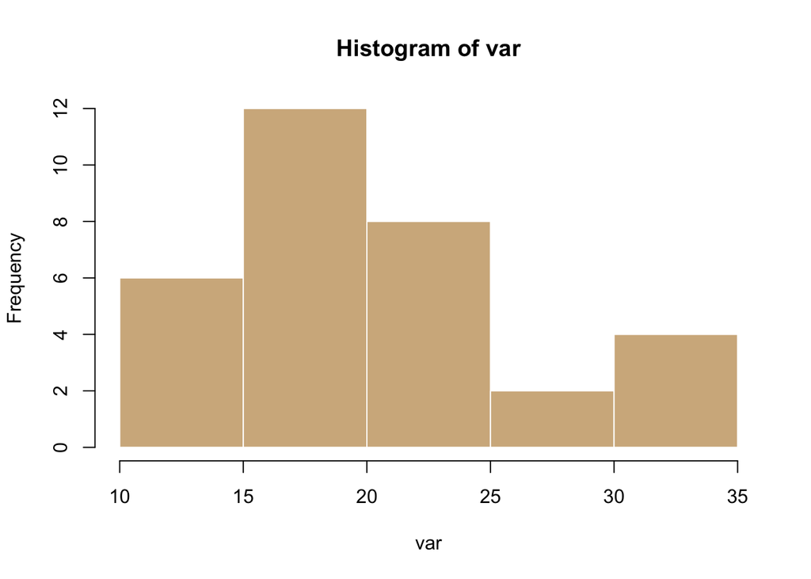

```r
myhist <- function(var, Color = "white", Fill = "tan"){
  hist(var, border = Color, col = Fill)
}
myhist(mtcars$mpg)
```

You can override these options if you want.

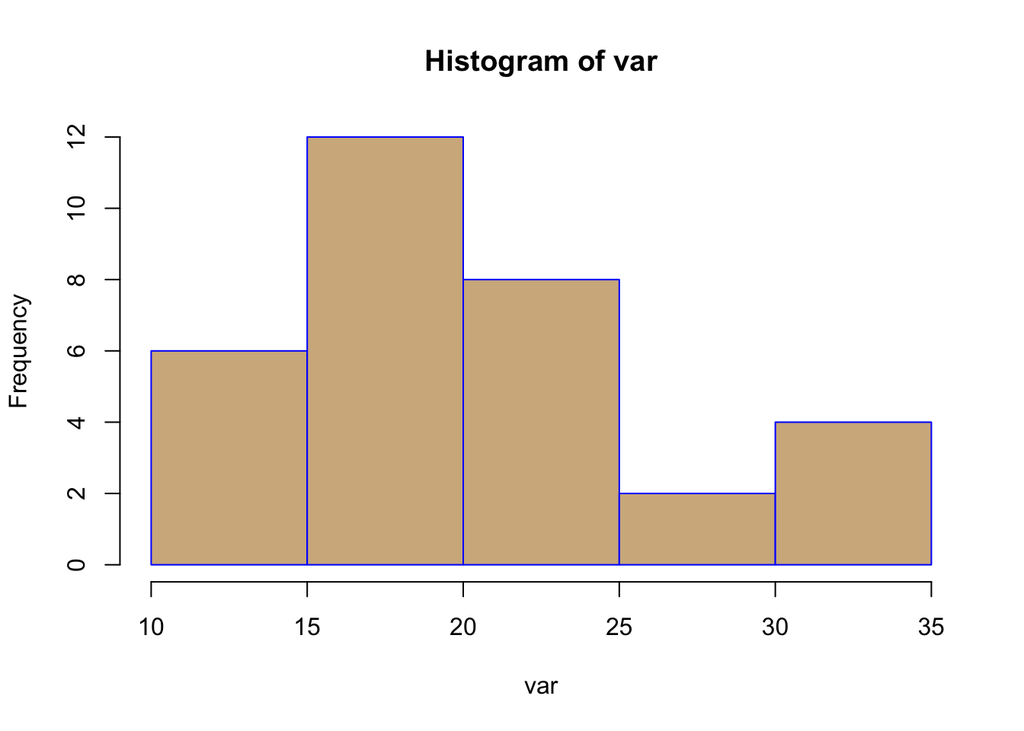

```r
myhist(mtcars$mpg, Color = "blue")
```

#### Question 4

The `plot` function is a simple way to construct a scatterplot of two vectors. Write a function `myplot` that accepts two vector inputs `x` and `y` and by default makes the color of the points blue (col = “blue”) and chooses a solid dot shape (pch = 19). Show that it works.

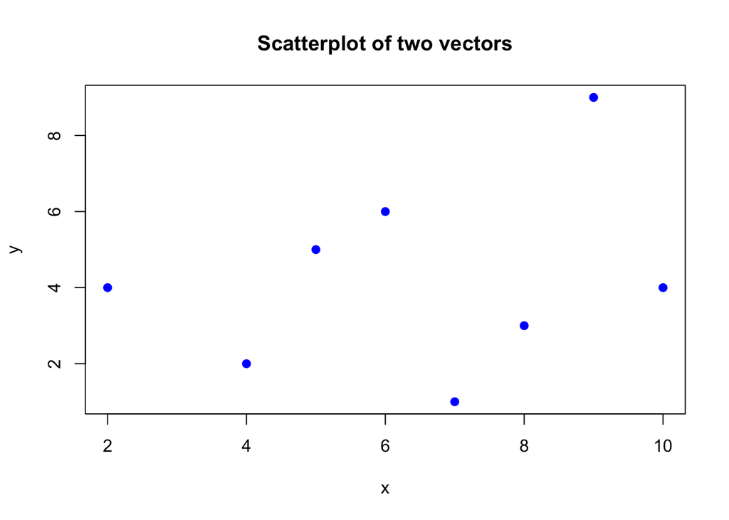

```r
  myplot <- function(x, y, col = "blue"){
  plot(x,y, pch = 19, col = col, main="Scatterplot of two vectors")

  }
x <- c(2,4,5,6,7,8,9,10)
y <- c(4,2,5,6,1,3,9,4)
myplot(x, y)
```

```r
 # myplot(mtcars$mpg)
```